# Bellabeat_Capstone

Nanke Williams

2022-09-29

### Introduction and Background

Bellabeat has 5 products: an app (Bellabeat app), a wellness tracker, a smart watch, a water bottle line and a subscription membership service.

The business task is to analyze user smart device data collected by the wearable technology and tracked on the app, in order to:

- gain insight into how customers are using their smart devices, and
- recommend appropriate marketing strategies for the company.

### Sourcing the Data

The Bellabeat dataset was sourced from [here](https://www.kaggle.com/arashnic/fitbit). The primary tables used in this analysis are:

- dailyActivity_merged.csv
- sleepDay_merged.csv
- weightLogInfo_merged.csv
- heartrate_records.csv

### Analysing the Credibility of the dataset

The data contains the following number of unique user records:

- dailyActivity_merged.csv - 33 records
- sleepDay_merged.csv - 24 records
- weightLogInfo_merged.csv - 8 records
- heartrate_records.csv - 14 records

There’s a very limited amount of data to analyze and make recommendations from. The data is accurate, original and comprehensive. But it is dated and not current.

### Preliminary analysis of the datasets

Preliminary analysis of the dataset was conducted in SQL. The following points were found:

- There are only 3 unique IDs identical to all 4 datasets. This sample is too small to analyze. We have chosen instead to prioritize the dailyActivity dataset and join relevant variables from the other datasets to it. A new summary dataset was created.
- There are null records across all variables in the largest dataset (dailyActivity)
- This will affect all cross data analysis and significantly reduce the sample size.

In R, we will perform correlation analysis and visualizations on some on the relationship between some of the variables.

### Installing and loading common packages and libraries

```r
# install.packages('tidyverse')
library(tidyverse)
```

### Loading your CSV files

We create variables and load the csv files into them.

```r
daily_activity <- read.csv("dailyActivity_merged.csv")
sleep_log <- read.csv("sleepDay_merged.csv")
weight_log <- read.csv("weightLogInfo_merged.csv")
heartrate_log <- read.csv("heartrate_records.csv")
summary_table <- read.csv('fitabasecollated_table.csv')
```

### Preliminary analysis

We conduct preliminary analysis of the tables using head(), glimpse(), str(), glimpse(), summary() methods to get an initial overview of the data.

```r
head(daily_activity)
```

```
##           Id ActivityDate TotalSteps TotalDistance TrackerDistance
## 1 1503960366      4/12/16      13162          8.50            8.50
## 2 1503960366      4/13/16      10735          6.97            6.97
## 3 1503960366      4/14/16      10460          6.74            6.74
## 4 1503960366      4/15/16       9762          6.28            6.28
## 5 1503960366      4/16/16      12669          8.16            8.16
## 6 1503960366      4/17/16       9705          6.48            6.48
##   LoggedActivitiesDistance VeryActiveDistance ModeratelyActiveDistance
## 1                        0               1.88                     0.55
## 2                        0               1.57                     0.69
## 3                        0               2.44                     0.40
## 4                        0               2.14                     1.26
## 5                        0               2.71                     0.41
## 6                        0               3.19                     0.78
##   LightActiveDistance SedentaryActiveDistance VeryActiveMinutes
## 1                6.06                       0                25
## 2                4.71                       0                21
## 3                3.91                       0                30
## 4                2.83                       0                29
## 5                5.04                       0                36
## 6                2.51                       0                38
##   FairlyActiveMinutes LightlyActiveMinutes SedentaryMinutes Calories
## 1                  13                  328              728     1985
## 2                  19                  217              776     1797
## 3                  11                  181             1218     1776
## 4                  34                  209              726     1745
## 5                  10                  221              773     1863
## 6                  20                  164              539     1728
```

```r
head(sleep_log)
```

```
##           Id              SleepDay TotalSleepRecords TotalMinutesAsleep
## 1 1503960366 4/12/2016 12:00:00 AM                 1                327
## 2 1503960366 4/13/2016 12:00:00 AM                 2                384
## 3 1503960366 4/15/2016 12:00:00 AM                 1                412
## 4 1503960366 4/16/2016 12:00:00 AM                 2                340
## 5 1503960366 4/17/2016 12:00:00 AM                 1                700
## 6 1503960366 4/19/2016 12:00:00 AM                 1                304
##   TotalTimeInBed
## 1            346
## 2            407
## 3            442
## 4            367
## 5            712
## 6            320
```

```r
head(weight_log)
```

```
##           Id                  Date WeightKg WeightPounds Fat   BMI
## 1 1503960366  5/2/2016 11:59:59 PM     52.6     115.9631  22 22.65
## 2 1503960366  5/3/2016 11:59:59 PM     52.6     115.9631  NA 22.65
## 3 1927972279  4/13/2016 1:08:52 AM    133.5     294.3171  NA 47.54
## 4 2873212765 4/21/2016 11:59:59 PM     56.7     125.0021  NA 21.45
## 5 2873212765 5/12/2016 11:59:59 PM     57.3     126.3249  NA 21.69
## 6 4319703577 4/17/2016 11:59:59 PM     72.4     159.6147  25 27.45
##   IsManualReport        LogId
## 1           True 1.462234e+12
## 2           True 1.462320e+12
## 3          False 1.460510e+12
## 4           True 1.461283e+12
## 5           True 1.463098e+12
## 6           True 1.460938e+12
```

```r
head(heartrate_log)
```

```
##           id total_recorded_days avg_heartrate
## 1 1503960366                   0          NULL
## 2 1624580081                   0          NULL
## 3 1644430081                   0          NULL
## 4 1844505072                   0          NULL
## 5 1927972279                   0          NULL
## 6 2022484408                  30            80
```

```r
head(summary_table)
```

```
##           id recorded_sleep_days recorded_activity_days
## 1 1503960366                  25                     30
## 2 1624580081                   0                     30
## 3 1644430081                   4                     30
## 4 1844505072                   3                     30
## 5 1927972279                   5                     30
## 6 2022484408                   0                     30
##   recorded_weightcheck_days sleep_records mins_asleep mins_in_bed  steps
## 1                         2            27        9007        9580 375619
## 2                         0            NA          NA          NA 178061
## 3                         0             4        1176        1384 218489
## 4                         0             3        1956        2883  79982
## 5                         1             8        2085        2189  28400
## 6                         0            NA          NA          NA 352490
##   distance sed_distance active_distance percent_active_distance
```

[output cut: 27 more lines]

This is the primary table to be used for this review.

str() shows us the column names, data types and a sample of the records in each variable.

```r
str(summary_table)
```

```
## 'data.frame':    33 obs. of  22 variables:
##  $ id                        : num  1.50e+09 1.62e+09 1.64e+09 1.84e+09 1.93e+09 ...
##  $ recorded_sleep_days       : int  25 0 4 3 5 0 27 1 15 0 ...
##  $ recorded_activity_days    : int  30 30 30 30 30 30 30 30 18 30 ...
##  $ recorded_weightcheck_days : int  2 0 0 0 1 0 0 0 0 2 ...
##  $ sleep_records             : int  27 NA 4 3 8 NA 28 1 15 NA ...
##  $ mins_asleep               : int  9007 NA 1176 1956 2085 NA 14173 61 6702 NA ...
##  $ mins_in_bed               : int  9580 NA 1384 2883 2189 NA 15054 69 7370 NA ...
##  $ steps                     : int  375619 178061 218489 79982 28400 352490 172573 146223 171354 234229 ...
##  $ distance                  : num  242.1 121.4 158.9 52.9 19.7 ...
##  $ sed_distance              : num  0 0.19 0.12 0 0 0 0 0 0 0.16 ...
##  $ active_distance           : num  242 121.1 158.7 52.9 19.7 ...
##  $ percent_active_distance   : num  100 99.8 99.9 100 100 ...
##  $ percent_sedentary_distance: num  0 0.16 0.08 0 0 0 0 0 0 0.1 ...
##  $ total_mins                : int  34905 44197 41138 41028 42101 44196 29339 44089 17527 44188 ...
##  $ sedentary_mins            : int  26293 38990 34856 37405 40840 34490 21372 37823 12369 34013 ...
##  $ active_mins               : int  8612 5207 6282 3623 1261 9706 7967 6266 5158 10175 ...
##  $ percent_active_mins       : num  24.67 11.78 15.27 8.83 3 ...
##  $ percent_sedentary_mins    : num  75.3 88.2 84.7 91.2 97 ...
##  $ calories                  : int  56309 45984 84339 48778 67357 77809 47760 53449 36782 59426 ...
##  $ avg_calories_per_day      : int  1816 1483 2811 1573 2173 2510 1541 1724 2043 1917 ...
##  $ avg_weight_kg             : num  52.6 NA NA NA 133.5 ...
##  $ avg_bmi                   : num  22.6 NA NA NA 47.5 ...
```

## Data Cleaning

For proper analysis, we will convert the following columns to appropriate datatypes:

- id column to character

```r
summary_table$id <- as.character(summary_table$id)
```

A glimpse of the table after cleaning.

```r
glimpse(summary_table)
```

```
## Rows: 33
## Columns: 22
## $ id                         <chr> "1503960366", "1624580081", "1644430081", "…
## $ recorded_sleep_days        <int> 25, 0, 4, 3, 5, 0, 27, 1, 15, 0, 0, 28, 8, …
## $ recorded_activity_days     <int> 30, 30, 30, 30, 30, 30, 30, 30, 18, 30, 20,…
## $ recorded_weightcheck_days  <int> 2, 0, 0, 0, 1, 0, 0, 0, 0, 2, 0, 0, 0, 0, 2…
## $ sleep_records              <int> 27, NA, 4, 3, 8, NA, 28, 1, 15, NA, NA, 32,…
## $ mins_asleep                <int> 9007, NA, 1176, 1956, 2085, NA, 14173, 61, …
## $ mins_in_bed                <int> 9580, NA, 1384, 2883, 2189, NA, 15054, 69, …
## $ steps                      <int> 375619, 178061, 218489, 79982, 28400, 35249…
## $ distance                   <dbl> 242.10, 121.36, 158.86, 52.89, 19.67, 250.6…
## $ sed_distance               <dbl> 0.00, 0.19, 0.12, 0.00, 0.00, 0.00, 0.00, 0…
## $ active_distance            <dbl> 241.97, 121.11, 158.70, 52.85, 19.66, 250.6…
## $ percent_active_distance    <dbl> 100.00, 99.84, 99.92, 100.00, 100.00, 100.0…
## $ percent_sedentary_distance <dbl> 0.00, 0.16, 0.08, 0.00, 0.00, 0.00, 0.00, 0…
## $ total_mins                 <int> 34905, 44197, 41138, 41028, 42101, 44196, 2…
## $ sedentary_mins             <int> 26293, 38990, 34856, 37405, 40840, 34490, 2…
## $ active_mins                <int> 8612, 5207, 6282, 3623, 1261, 9706, 7967, 6…
## $ percent_active_mins        <dbl> 24.67, 11.78, 15.27, 8.83, 3.00, 21.96, 27.…
## $ percent_sedentary_mins     <dbl> 75.33, 88.22, 84.73, 91.17, 97.00, 78.04, 7…
## $ calories                   <int> 56309, 45984, 84339, 48778, 67357, 77809, 4…
## $ avg_calories_per_day       <int> 1816, 1483, 2811, 1573, 2173, 2510, 1541, 1…
## $ avg_weight_kg              <dbl> 52.6, NA, NA, NA, 133.5, NA, NA, NA, NA, 57…
## $ avg_bmi                    <dbl> 22.65, NA, NA, NA, 47.54, NA, NA, NA, NA, 2…
```

Everything looks ready for analysis.

### Summary statistics

First, some summary statistics to view statistical information on all variables.

```r
summary(summary_table)
```

```
##       id            recorded_sleep_days recorded_activity_days
##  Length:33          Min.   : 0.00       Min.   : 4.00
##  Class :character   1st Qu.: 0.00       1st Qu.:29.00
##  Mode  :character   Median : 5.00       Median :30.00
##                     Mean   :12.21       Mean   :27.85
##                     3rd Qu.:26.00       3rd Qu.:30.00
##                     Max.   :30.00       Max.   :30.00
##
##  recorded_weightcheck_days sleep_records    mins_asleep     mins_in_bed
##  Min.   : 0.00             Min.   : 1.00   Min.   :   61   Min.   :   69
##  1st Qu.: 0.00             1st Qu.: 4.75   1st Qu.: 1761   1st Qu.: 1988
##  Median : 0.00             Median :23.00   Median : 8420   Median : 9382
##  Mean   : 1.97             Mean   :19.25   Mean   : 7218   Mean   : 7892
##  3rd Qu.: 0.00             3rd Qu.:30.25   3rd Qu.:11372   3rd Qu.:12509
##  Max.   :29.00             Max.   :39.00   Max.   :14368   Max.   :15682
##                            NA's   :9       NA's   :9       NA's   :9
##      steps           distance       sed_distance     active_distance
##  Min.   : 15352   Min.   : 11.45   Min.   :0.00000   Min.   : 11.22
##  1st Qu.:146223   1st Qu.: 98.82   1st Qu.:0.00000   1st Qu.: 98.73
##  Median :223154   Median :157.50   Median :0.00000   Median :141.55
##  Mean   :218667   Mean   :157.25   Mean   :0.04576   Mean   :155.01
##  3rd Qu.:290525   3rd Qu.:208.40   3rd Qu.:0.02000   3rd Qu.:208.39
##  Max.   :497241   Max.   :409.60   Max.   :0.25000   Max.   :408.08
##
##  percent_active_distance percent_sedentary_distance   total_mins
##  Min.   : 99.65          Min.   :0.00000            Min.   : 5290
##  1st Qu.: 99.99          1st Qu.:0.00000            1st Qu.:30142
##  Median :100.00          Median :0.00000            Median :34905
##  Mean   : 99.96          Mean   :0.03879            Mean   :34812
##  3rd Qu.:100.00          3rd Qu.:0.01000            3rd Qu.:42101
##  Max.   :100.00          Max.   :0.35000            Max.   :44559
##
##  sedentary_mins   active_mins    percent_active_mins percent_sedentary_mins
##  Min.   : 4869   Min.   :  421   Min.   : 3.00       Min.   :69.76
##  1st Qu.:22633   1st Qu.: 5207   1st Qu.:11.84       1st Qu.:75.05
##  Median :26833   Median : 7250   Median :21.96       Median :78.04
##  Mean   :28300   Mean   : 6512   Mean   :19.15       Mean   :80.85
##  3rd Qu.:34598   3rd Qu.: 8529   3rd Qu.:24.95       3rd Qu.:88.16
##  Max.   :40840   Max.   :10175   Max.   :30.24       Max.   :97.00
##
##     calories      avg_calories_per_day avg_weight_kg       avg_bmi
##  Min.   :  7895   Min.   :1483         Min.   : 52.60   Min.   :21.57
##  1st Qu.: 53449   1st Qu.:1917         1st Qu.: 60.45   1st Qu.:23.68
##  Median : 63168   Median :2132         Median : 71.00   Median :26.35
##  Mean   : 65939   Mean   :2283         Mean   : 77.81   Mean   :27.99
##  3rd Qu.: 79557   3rd Qu.:2600         3rd Qu.: 86.50   3rd Qu.:27.56
##  Max.   :110539   Max.   :3454         Max.   :133.50   Max.   :47.54
##                                        NA's   :25       NA's   :25
```

Some variables (such as avg_weight_kg,avg_bmi, sleep_records, mins_asleep, mins_in_bed contain significant null values which will affect visual analysis)

A brief summary of select columns from each table (daily_activity, sleepday and weightlog_info), shows the following: Daily Activity Table - Steps

```r
summary(summary_table$steps)
```

```
##    Min. 1st Qu.  Median    Mean 3rd Qu.    Max.
##   15352  146223  223154  218667  290525  497241
```

Sleep Log Table - minutes asleep

```r
summary(summary_table$mins_asleep)
```

```
##    Min. 1st Qu.  Median    Mean 3rd Qu.    Max.    NA's
##      61    1761    8420    7218   11372   14368       9
```

Weight Log Table - average weight in kilograms

```r
summary(summary_table$avg_weight_kg)
```

```
##    Min. 1st Qu.  Median    Mean 3rd Qu.    Max.    NA's
##   52.60   60.45   71.00   77.81   86.50  133.50      25
```

#### Visualizing the Data

First, we measure correlation between the relevant variables and then visualize that correlation in a scatter plot.

- A correlation coefficient is a metric that measures the extent to which numeric variables are associated with one another.
- The correlation coefficient always lies between +1 (perfect positive correlation) and –1 (perfect negative correlation); 0 indicates no correlation.

Measure correlation between active distance and active minutes

```r
cor(x= summary_table$active_distance, y = summary_table$active_mins, use = 'complete.obs', method = 'pearson')
```

```
## [1] 0.7603857
```

This shows significant association between the variables. Let’s confirm with a scatterplot chart.

Chart relationship between active minutes and active distance

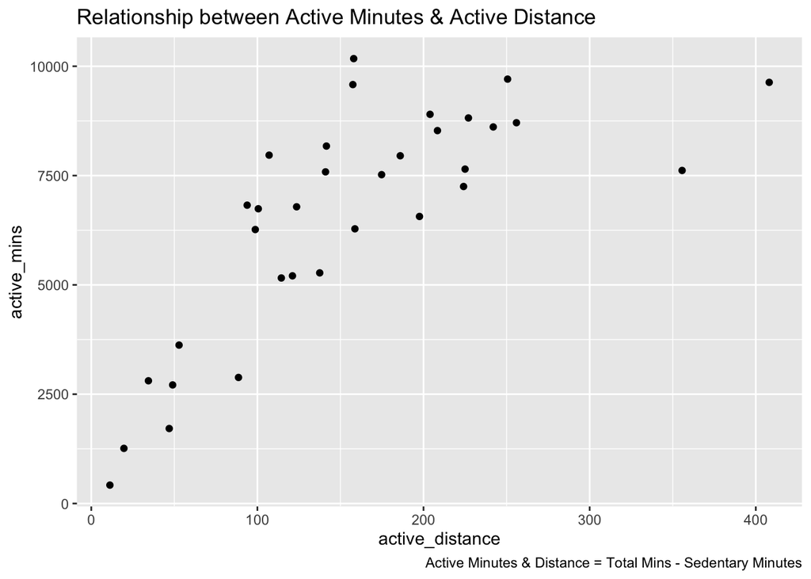

```r
ggplot(data = summary_table) +
  geom_point(mapping = aes(x = active_distance, y = active_mins)) +
  labs(title = 'Relationship between Active Minutes & Active Distance',
       caption = 'Active Minutes & Distance = Total Mins - Sedentary Minutes')
```

Measure correlation betwen steps and active distance

```r
cor(x= summary_table$active_distance, y = summary_table$steps, use = 'everything', method = 'pearson')
```

```
## [1] 0.986674
```

Chart relationship between steps and active distance

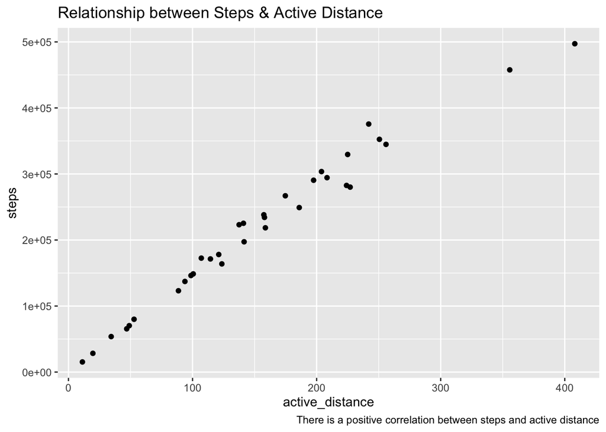

```r
ggplot(data = summary_table) +
  geom_point(mapping = aes(x = active_distance, y = steps)) +
  labs(title = 'Relationship between Steps & Active Distance',
       caption = 'There is a positive correlation between steps and active distance')
```

Measure correlation between calories and active minutes

```r
cor(x= summary_table$calories, y = summary_table$active_mins, use = 'everything', method = 'pearson')
```

```
## [1] 0.4623992
```

Chart relationship between calories and active minutes

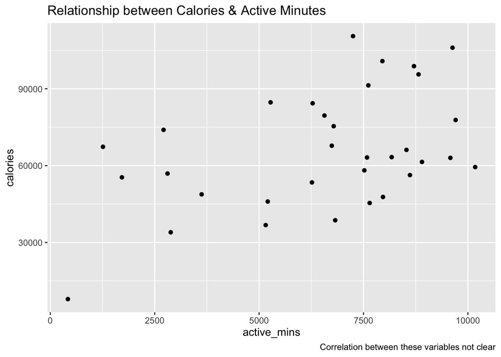

```r
ggplot(data = summary_table) +
  geom_point(mapping = aes(x = active_mins, y = calories)) +
  labs(title = 'Relationship between Calories & Active Minutes',
       caption = 'Correlation between these variables not clear')
```

The relationship between these variables are not distint enough. More data is needed to confirm or exclude any conclusions about correlation.

Measure correlation between steps and average bmi

```r
cor(x= summary_table$steps, y = summary_table$avg_bmi, use = 'complete.obs', method = 'pearson')
```

```
## [1] -0.7351036
```

There is a significant negative correlation between bmi and step activity. This will be clearer with a visual graph.

Chart relationship between steps and avg_bmi

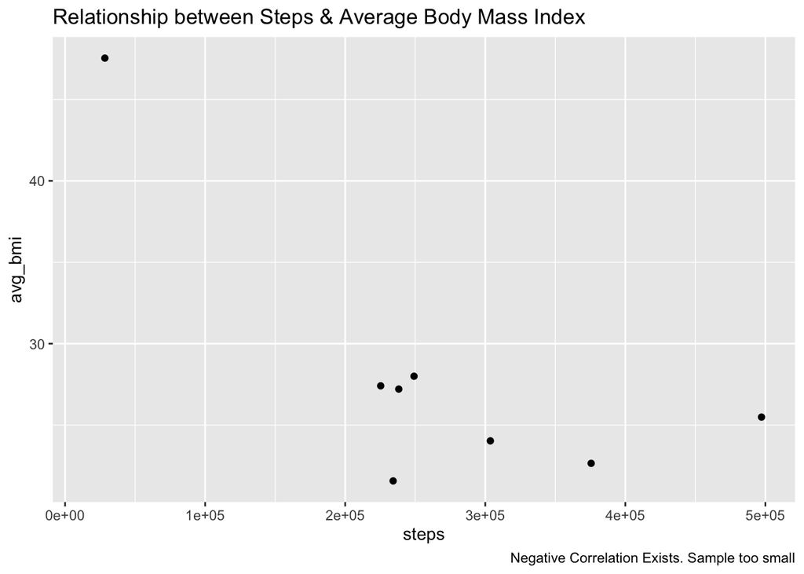

```r
ggplot(data = summary_table) +
  geom_point(mapping = aes(x = steps, y = avg_bmi)) +
  labs(title = 'Relationship between Steps & Average Body Mass Index',
       caption = 'Negative Correlation Exists. Sample too small')
```

Unfortunately, the number of records available for this chart (8 records) is too small to make any final conclusions.

Measure correlation between steps and average weight

```r
cor(x= summary_table$steps, y = summary_table$avg_weight_kg, use = 'complete.obs', method = 'pearson')
```

```
## [1] -0.571218
```

Chart relationship between steps and avg_weight

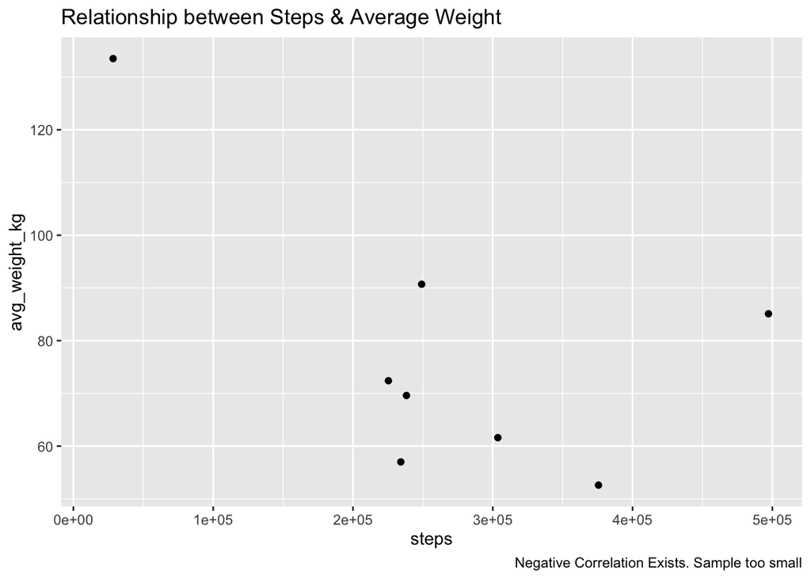

```r
ggplot(data = summary_table) +
  geom_point(mapping = aes(x = steps, y = avg_weight_kg)) +
    labs(title = 'Relationship between Steps & Average Weight',
       caption = 'Negative Correlation Exists. Sample too small')
```

Measure correlation between steps and minutes asleep

```r
cor(x= summary_table$steps, y = summary_table$mins_asleep, use = 'complete.obs', method = 'pearson')
```

```
## [1] 0.2962524
```

There is no significant correlation between active steps and minutes asleep. The visual chart will show this much clearly.

Chart relationship between steps and mins_asleep

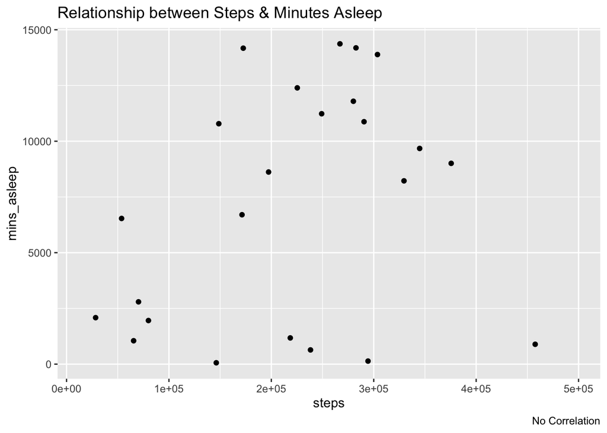

```r
ggplot(data = summary_table) +
  geom_point(mapping = aes(x = steps, y = mins_asleep)) +
    labs(title = 'Relationship between Steps & Minutes Asleep',
       caption = 'No Correlation')
```

Measure correlation between calories and minutes asleep

```r
cor(x= summary_table$calories, y = summary_table$mins_asleep, use = 'complete.obs', method = 'pearson')
```

```
## [1] 0.1818075
```

Chart relationship between calories and mins_asleep

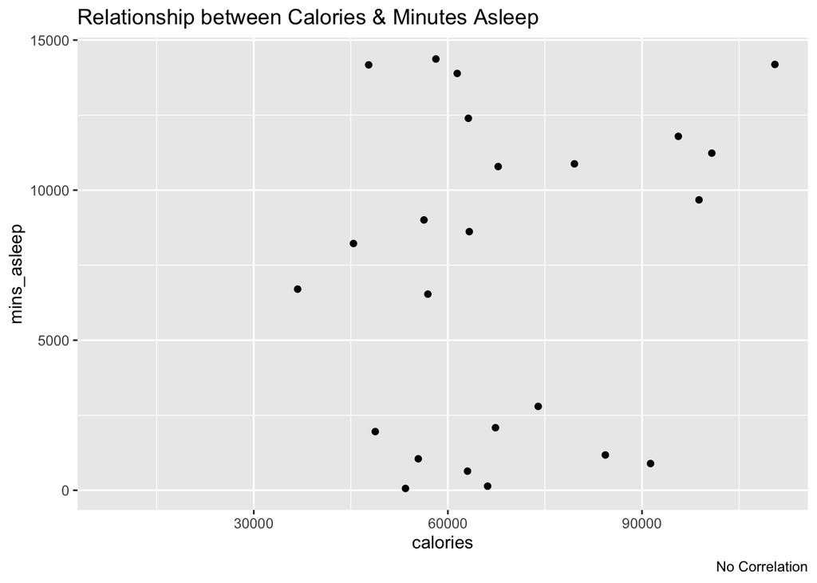

```r
ggplot(data = summary_table) +
  geom_point(mapping = aes(x = calories, y = mins_asleep)) +
      labs(title = 'Relationship between Calories & Minutes Asleep',
       caption = 'No Correlation')
```

Measure correlation between minutes asleep and active minutes

```r
cor(x= summary_table$mins_asleep, y = summary_table$active_mins, use = 'complete.obs', method = 'pearson')
```

```
## [1] 0.4375908
```

Chart relationship between minutes asleep and active minutes

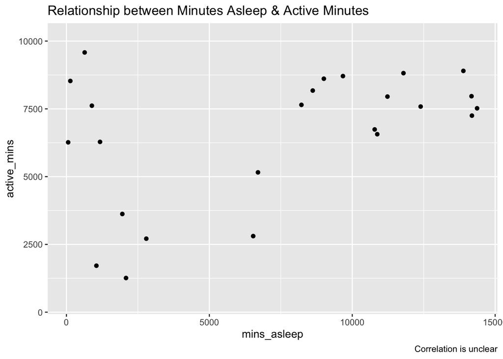

```r
ggplot(data = summary_table) +
  geom_point(mapping = aes(x = mins_asleep, y = active_mins)) +
      labs(title = 'Relationship between Minutes Asleep & Active Minutes',
       caption = 'Correlation is unclear')
```

Measure correlation between calories and average weight

```r
cor(x= summary_table$calories, y = summary_table$avg_weight_kg, use = 'complete.obs', method = 'pearson')
```

```
## [1] 0.3671638
```

Chart relationship between calories and average weight

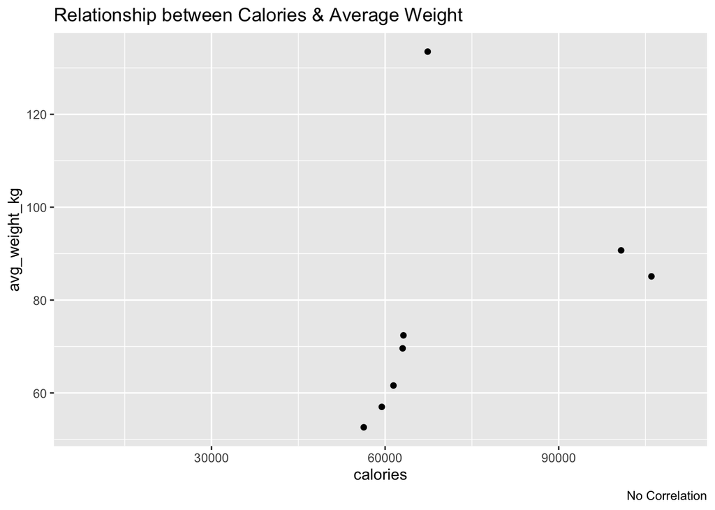

```r
ggplot(data = summary_table) +
  geom_point(mapping = aes(x = calories, y = avg_weight_kg)) +
      labs(title = 'Relationship between Calories & Average Weight',
       caption = 'No Correlation')
```

#### Conclusion from Analysis

Here are some recommendations from the analysis of the dataset:

- Bellabeat should provide more data for analysis
- Bellabeat should market to its users via regular reminders on the Bellabeat app, that they wear their smart technology
- Although a small sample size, the negative correlation between step activity and average body mass index and average weight is a positive metric. This should be highlighted to users
- Important correlations could not be properly determined because of the small sample size - e.g. the relationship between calories, activity, sleep and weight is not clear.